# Laboratorio43-MD

Leislie R. Manjarrez O.

2023-03-07

Hecho con gusto por Leislie R. Manjarrez O.

Laboratorio 43- Mapa de calor termico con pheatmap DATOS GENETICOS TOMADOS DE Sahir Bhatnagar. PRACTICA DE CODERS

Objetivo: Realizar un heatmap con datos geneticos En este ejercicio vamos a: 1. Cargar nuestra matriz hipotetica de datos y dataframes adicionales 2. Realizar varios heatmaps

Un mapa de calor es una representacion grafica de datos que utiliza un sistema de codificacion de colores para representar diferentes valores

Primero instalar la paquetería install.packages(“pheatmap”)

Llamar a la libreria

```r
library(pheatmap)
```

Importar datos para realizar el laboratorio. Para este caso son 3 archivos a utilizar

```r
file.choose()
```

```
## [1] "C:\\Users\\leisl\\OneDrive\\Doctorado\\Semestre-3\\Temas-Selectos-1-Complejidad-Económica\\Modulo3\\Semana7-Labs-Salas-Cápsulas\\Lab43\\heatmap_data.csv"
```

Creamos un objeto con estructura matricial con el primer archivo

```r
genes <- as.matrix(read.csv("heatmap_data.csv",
                            sep = ",",
                            header = T,
                            row.names = 1))
```

Realizamos lo mismo con el segundo archivo, solo que no se crea como matriz el objeto

```r
annotation_col <- read.csv ("annotation_col.csv",
                            header = T,
                            row.names = 1)
```

```r
annotation_row <- read.csv ("annotation_row.csv",
                            header = T,
                            row.names = 1)
```

Visualimos los objetos creados

```r
head(annotation_col)
```

```
##          Exposure   Type
## Patient1      X=0 T-cell
## Patient2      X=0 T-cell
## Patient3      X=0 B-cell
## Patient4      X=0 B-cell
## Patient5      X=0 B-cell
## Patient6      X=0 T-cell
```

```r
head(annotation_row)
```

```
##       Pathway
## Gene1       1
## Gene2       1
## Gene3       1
## Gene4       1
## Gene5       1
## Gene6       1
```

```r
head(genes)
```

```
##         Patient1    Patient2    Patient3    Patient4   Patient5    Patient6
## Gene1 -0.1914190 -1.23415247 -0.04346178  0.14572108 -0.4017205 -0.47780933
## Gene2 -0.8978632  0.39549549  0.56691534 -0.59602679 -0.5403446  0.30994709
## Gene3  1.0639177  2.79564490 -0.49031509 -0.64460585  0.8419138 -0.03060928
## Gene4  0.3524772  0.07475244  0.15824275  0.06590853  1.0301932 -0.75700251
## Gene5 -0.5016748  0.21616881 -0.86702910  2.05925069 -0.2852306  0.38657171
## Gene6  0.8912122  0.19006278  0.45290320  0.22524625 -1.3451477  0.19676648
##          Patient7   Patient8    Patient9  Patient10   Patient11  Patient12
## Gene1  0.72489958 -0.8400540 -0.26876091  0.8554139 -0.38300228  2.1056414
## Gene2 -2.56387048 -0.8002420 -0.93974510 -1.4978654  1.05754874 -0.1412128
## Gene3  1.21073382  0.2117729 -1.80738611 -0.1644144 -0.93277688 -0.7008772
## Gene4 -0.06960328 -0.6135344 -0.97209294 -1.9856584  0.33354084 -0.3210905
## Gene5 -0.61616107  0.3948389  0.01428765  0.1381662 -1.24444669  1.0542546
## Gene6  0.87490575  1.8090748  0.56535820 -1.3780365  0.02064252  0.7432685
##        Patient13  Patient14  Patient15   Patient16  Patient17  Patient18
## Gene1 -2.0796547  0.3926738 -0.3275861  0.06475283 -0.9468868  2.2042625
## Gene2  0.1824537  0.7270752  0.7598014 -0.79105318  1.1075292 -1.2417662
## Gene3  0.7580885 -0.4085302 -0.5938818 -2.21024093  0.3202009 -0.3225851
## Gene4 -1.7248673 -0.8580878 -0.8287558  0.10434044 -0.4613396 -1.5759535
## Gene5 -0.8787687  0.4198948  0.6714675 -1.50933762  0.5416448 -0.5347452
## Gene6 -0.3934806 -0.2330466  1.9699721  0.67023026  0.0777672 -0.3915463
##        Patient19  Patient20   Patient21   Patient22   Patient23   Patient24
## Gene1  0.1305819 -0.9590820  0.01324484  0.13116034 -0.39338267 -0.86842820
## Gene2  1.4334107  0.6888356  0.19155636  0.04112143 -0.05389741 -2.28008430
## Gene3 -0.5807339 -0.5930431  0.91492888  0.48364813  0.45701613 -0.53466053
## Gene4 -2.3485178 -0.1821325  1.15552779 -0.71283716  0.51263785  0.91432865
## Gene5 -1.0311090 -0.4013906  0.63063044 -0.17180124 -0.39731650 -0.02896519
## Gene6 -0.7518261  1.1974742 -2.38884049 -1.00750636 -0.76215238 -0.46993625
##        Patient25   Patient26  Patient27   Patient28  Patient29  Patient30
## Gene1  0.8049046  1.13419598  2.2361832  1.98108224 -1.5605465 -0.3719644
## Gene2 -0.7984835  0.52352075 -0.6941869  0.44401674 -1.2257144 -0.3365469
## Gene3 -0.9064944 -0.05174234 -0.9536200 -0.52797919  2.1410835  0.1145885
## Gene4  1.8500087  1.08404478 -0.2339720  1.04833856  0.2042004  1.1052790
## Gene5 -0.1089267 -0.68282587 -1.3068335  1.41365938  0.5630042  0.4840631
## Gene6  0.2788190 -1.14006748  0.4499973 -0.02990369  0.1661135  0.2607776
##        Patient31  Patient32  Patient33  Patient34   Patient35   Patient36
## Gene1 -0.3840099 -1.1273078  0.1871252  0.1475202  0.03237855 -0.42900425
## Gene2 -0.8503873  1.4977985  0.2566567 -3.1752249 -0.94983592 -0.72350860
## Gene3  0.5241392 -0.9540873 -1.4425236 -0.6800585 -0.14691688 -0.50635095
## Gene4 -0.5244872 -1.4009811  1.3371564  0.5631570  1.29972910 -0.45795799
```

[output cut: 64 more lines]

```
## Gene6 -0.4371058 -0.75481756  1.997926 -0.38433254  0.48732131 -0.80311326
##       Patient91  Patient92  Patient93  Patient94  Patient95 Patient96
## Gene1 1.0082713 -1.1387438 -0.3013357 -1.5809698 -1.4174691 1.8197438
## Gene2 1.2946590 -1.3506249 -0.7065800 -0.9575529 -0.9023188 2.1331045
## Gene3 0.9955628 -1.3143317 -0.2995042 -0.4976484 -0.7629150 1.8045605
## Gene4 0.9588467 -1.1112996 -0.4288897 -1.1036385 -0.4148775 1.3249769
## Gene5 1.1997252 -0.7535715 -0.3499271 -1.6749291 -0.7465204 0.9305900
## Gene6 1.4514865 -1.1020250 -0.4133264 -1.7403712 -0.9174716 0.3268849
##         Patient97 Patient98 Patient99 Patient100
## Gene1  0.17188029  1.823032 0.4342243 -0.6986283
## Gene2 -0.52896430  1.116291 0.5419882 -1.0395483
## Gene3 -0.48371973  1.391186 0.6750507 -1.4937080
## Gene4 -0.08633347  1.222353 0.8210392 -1.3347219
## Gene5 -0.19508380  1.391158 0.6028290 -1.0537915
## Gene6 -0.11497634  1.037765 0.3437560 -1.1895746
```

Generar el grafico con pheatmap. Es importante señalar que los clusters (dendrogramas) se generan de forma automática

```r
pheatmap(genes)
```

[output not shown]

Cambiar el tamaño de la fuente

```r
pheatmap(genes, frontsize = 6)
```

[output not shown]

Por default R clustea los renglores, en este caso los genes estan en los reglones y es lo que clustea. Para quitar el dendrograma de los pacientes (eje de la x) utilizamos las siguientes instrucciones

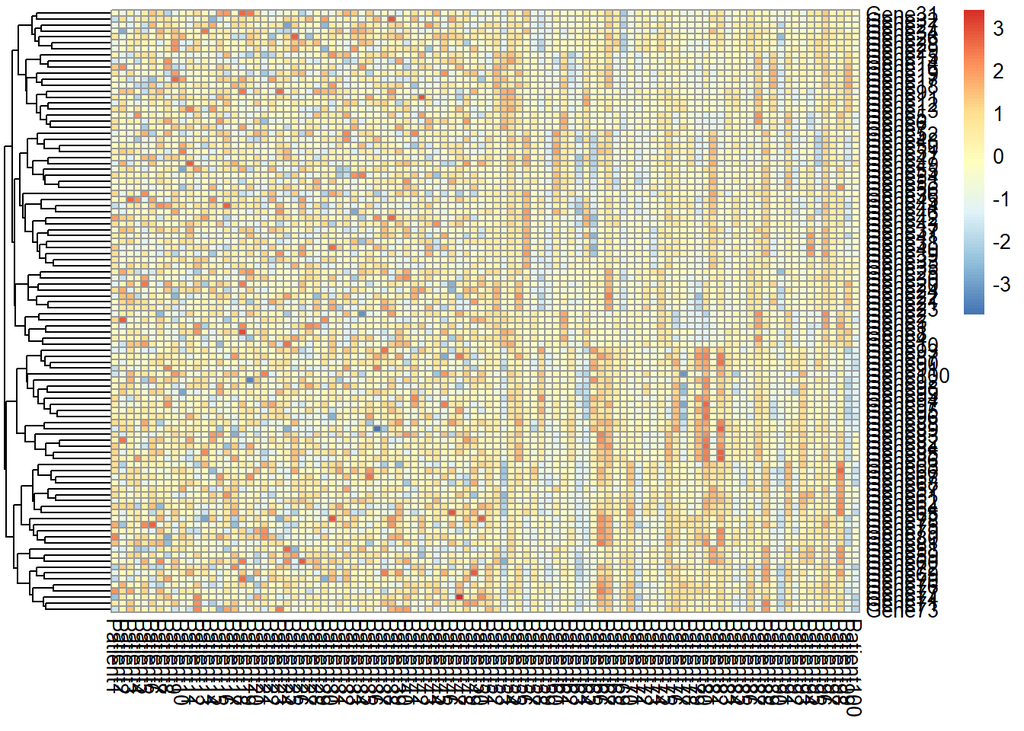

```r
pheatmap(genes, frontsize = 6, cluster_rows = T, cluster_cols = F)
```

Como práctica ahora hacemos lo contrario, eliminamos los genes (eje de la y) dejando a los pacientes

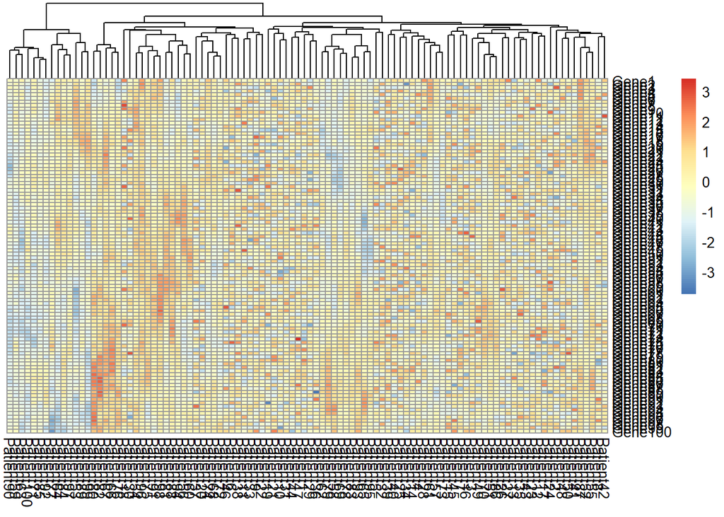

```r
pheatmap(genes, frontsize = 6, cluster_rows = F, cluster_cols = T)
```

Para regresar al grafico original

```r
pheatmap(genes, frontsize = 6, cluster_rows = T, cluster_cols = T)
```

[output not shown]

Para ver patrones subyacentes a las anotaciones de los renglones

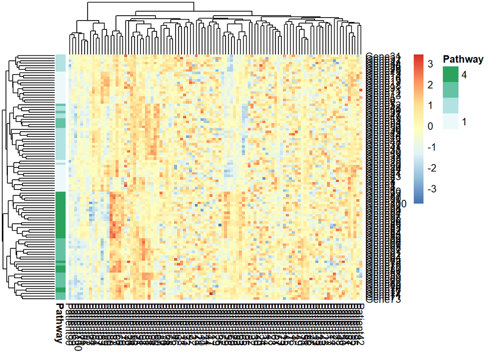

```r
pheatmap(genes, frontsize = 6, cluster_rows = T, cluster_cols = T, annotation_row = annotation_row)
```

Para ver patrones subyacentes a las anotaciones de los renglones y las columnas

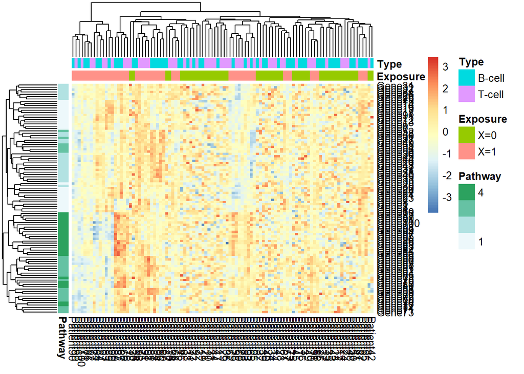

```r
pheatmap(genes, frontsize = 6, cluster_rows = T, cluster_cols = T, annotation_row = annotation_row, annotation_col = annotation_col)
```

Para quitar dendrogramas y colocar un título

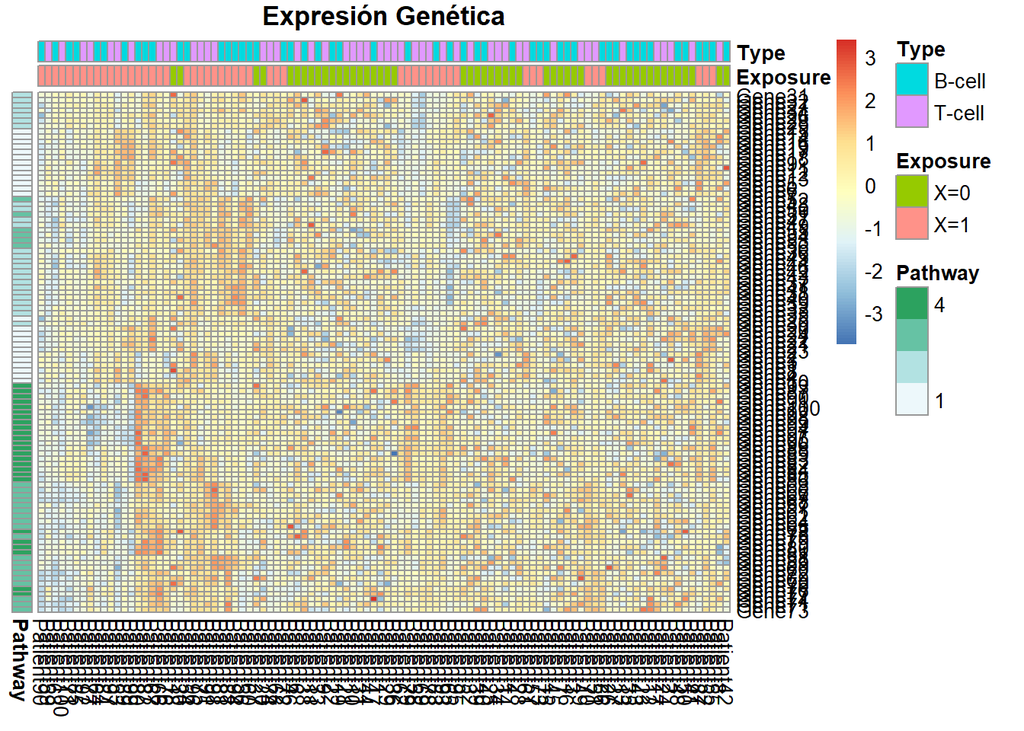

```r
pheatmap(genes, frontsize = 6, cluster_rows = T, cluster_cols = T, annotation_row = annotation_row, annotation_col = annotation_col, treeheight_row = 0, treeheight_col = 0, main = "Expresión Genética")
```

Para extraer datos de forma específico (un subconjunto de la totalidad), se crea objeto con ciertas caracteristicas

```r
sub <- genes [c(1:5, 55:60), c(1:5, 20:35, 55:60)]
```

Para graficar el nuevo objeto o subconjunto de datos reciclamos el codigo y solo cambiamos genes por sub

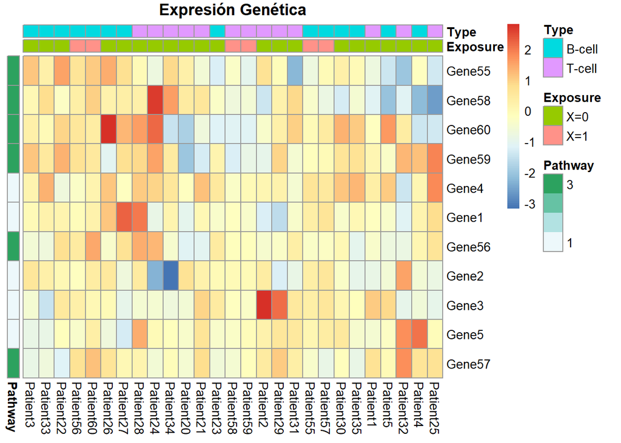

```r
pheatmap(sub, frontsize = 6, cluster_rows = T, cluster_cols = T, annotation_row = annotation_row, annotation_col = annotation_col, treeheight_row = 0, treeheight_col = 0, main = "Expresión Genética")
```

Para aumentar el tamano de las columnas sea mayor, no aparezca la anotacion de las leyendas y desplegar los número dando un tamano

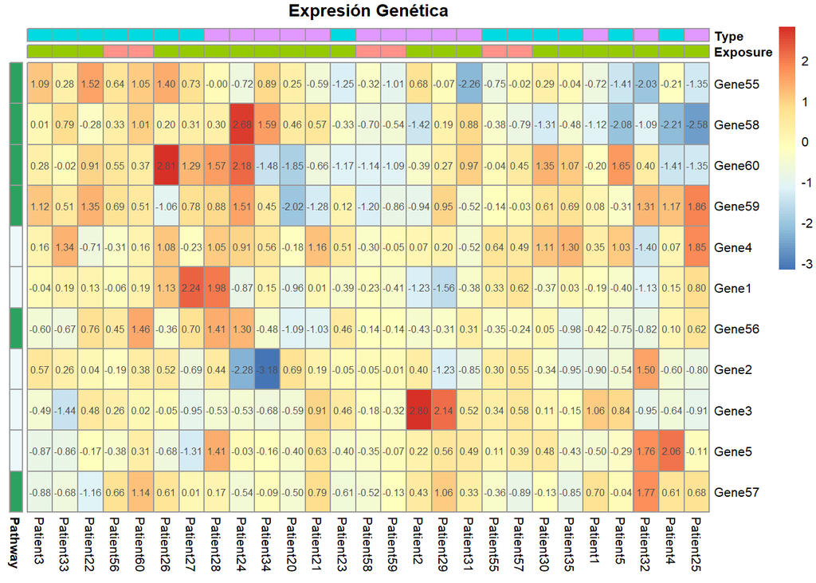

```r
pheatmap(sub, frontsize = 6, cluster_rows = T, cluster_cols = T, annotation_row = annotation_row, annotation_col = annotation_col, treeheight_row = 0, treeheight_col = 0, main = "Expresión Genética", fontsize = 8, annotation_legend = FALSE,  display_numbers = TRUE, fontsize_number = 6)
```

Para cambiar color llamar la paqueteria de viridis

```r
library(viridis)
```

Reciclamos codigo anterior y con viridis llamamos a la opcion plasma, magma, viridis, inferno

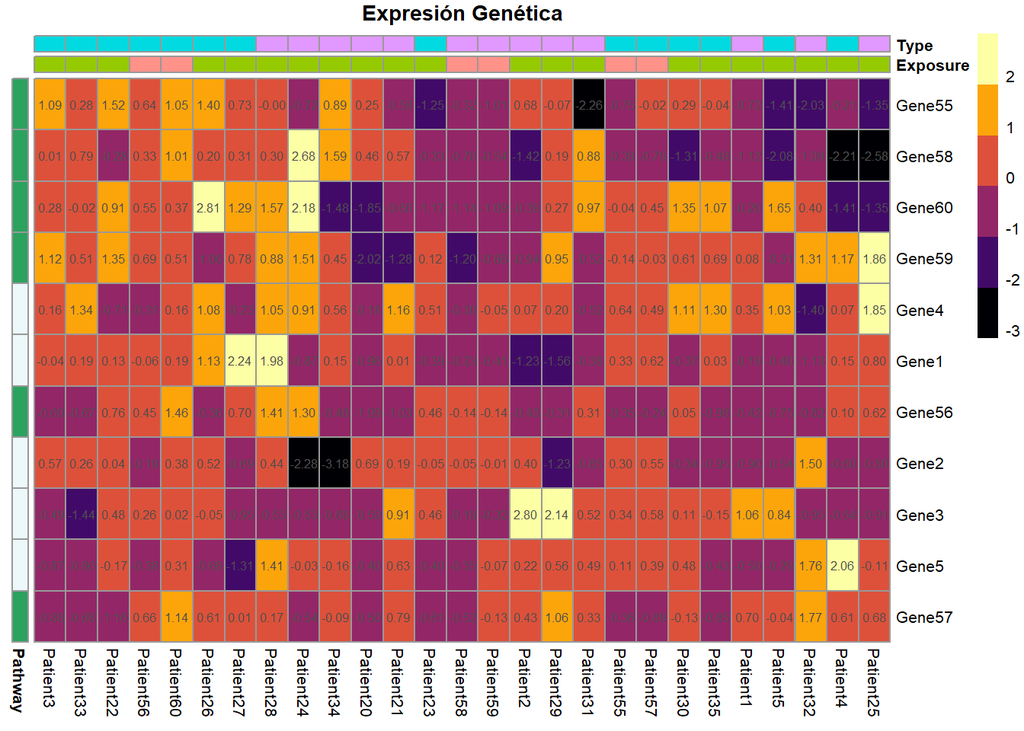

```r
pheatmap(sub, frontsize = 6, cluster_rows = T, cluster_cols = T, annotation_row = annotation_row, annotation_col = annotation_col, treeheight_row = 0, treeheight_col = 0, main = "Expresión Genética", fontsize = 8, annotation_legend = FALSE,         display_numbers = TRUE, fontsize_number = 6, col = viridis_pal(option = "inferno") (6))
```

Para visualizar la distancia entre los genes

```r
dist(sub)
```

```
##           Gene1    Gene2    Gene3    Gene4    Gene5   Gene55   Gene56   Gene57
## Gene2  6.506125
## Gene3  7.823569 7.021725
## Gene4  5.253565 7.649124 6.516104
## Gene5  6.411847 5.977640 5.967513 6.184570
## Gene55 5.703940 6.969997 7.096321 6.837653 7.534618
## Gene56 4.544832 6.723925 6.542745 5.805165 5.150859 6.028094
## Gene57 6.124657 6.069362 5.550487 6.004035 3.881691 7.122986 5.209746
## Gene58 7.417422 8.796956 8.462521 7.874145 8.030439 6.777444 6.292359 7.669524
## Gene59 6.189649 8.293720 7.977707 6.115718 5.821355 7.317126 4.835770 6.104449
## Gene60 6.623226 8.133474 7.665999 6.837342 7.659167 7.569942 6.373711 7.296198
##          Gene58   Gene59
## Gene2
## Gene3
## Gene4
## Gene5
## Gene55
## Gene56
## Gene57
## Gene58
## Gene59 8.312043
## Gene60 7.813793 6.992657
```

Para identificar el mapa de calor de la correlacion de los datos en este caso de los pacientes

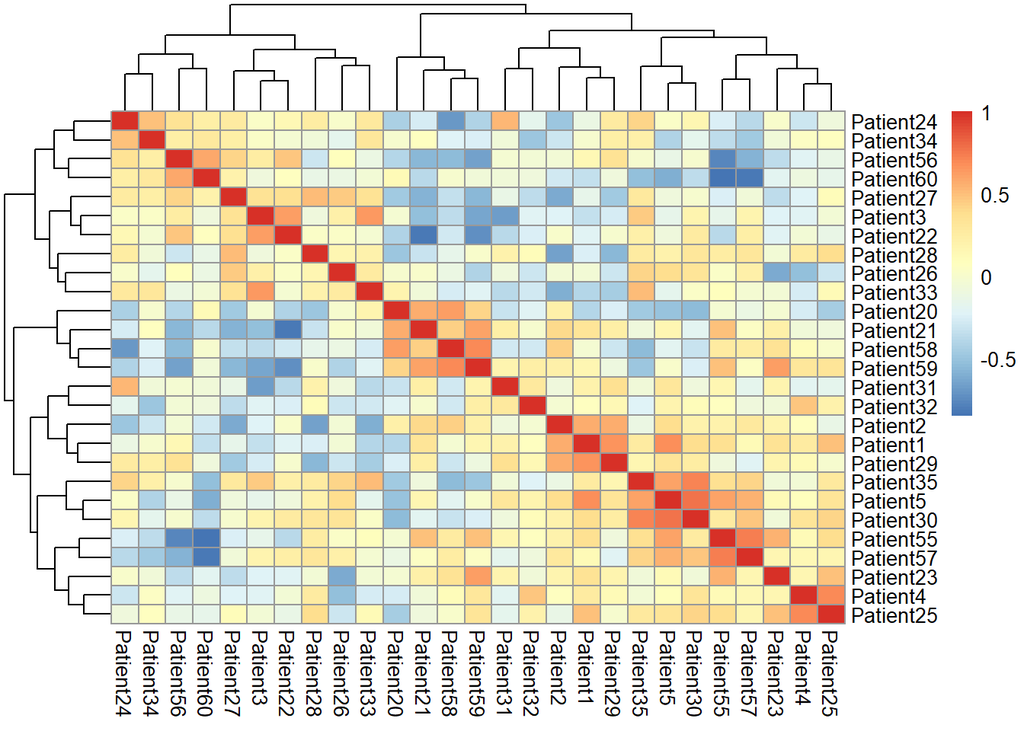

```r
pheatmap(cor(sub))
```

Generamos un objeto con la matriz transpuesta y generamos mapa genes y no pacientes

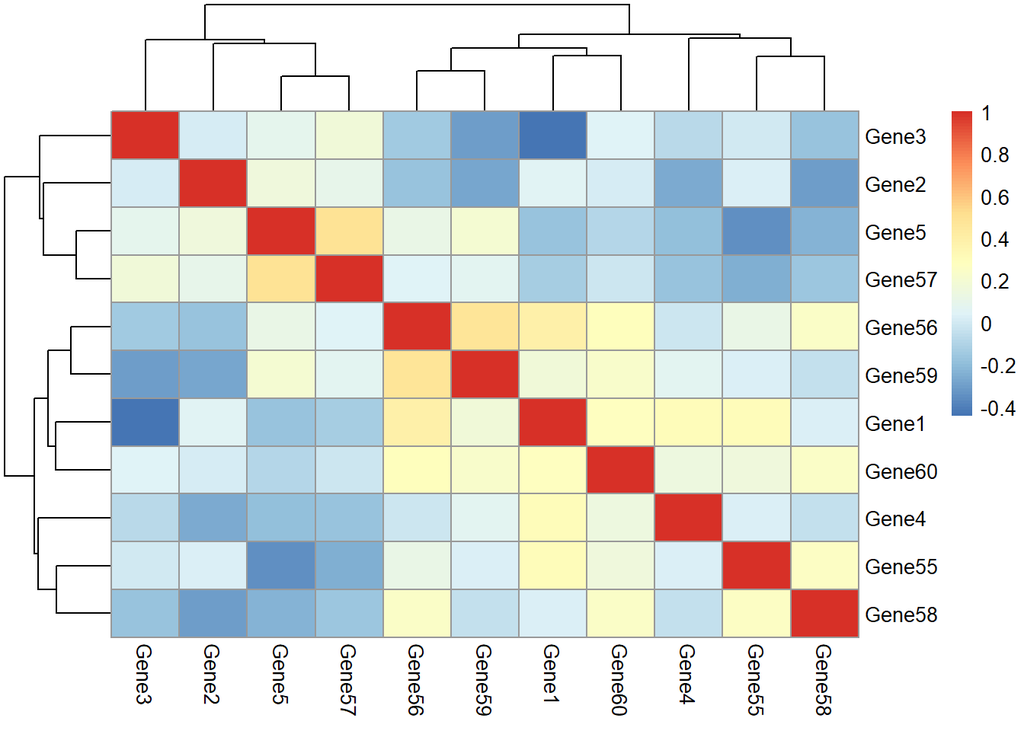

```r
trans <- t(sub)
pheatmap(cor(trans))
```